# Bias-Variance Trade-off

Dr. Josh Jacobson

14 January 2026

*These lecture notes were originally developed by Dr. Kris Pruitt.*

The purpose of this lesson is to explain and demonstrate the trade-off between bias error and variance error in statistical modeling. Specifically, we explore the impact on root mean squared error (RMSE) for increasingly flexible models of a non-linear association.

# Flexible versus Inflexible Models

In the previous lesson, we explored a data set involving fish caught in a Finnish lake. We import the same data below and split it into training and testing sets prior to modeling.

```r
# import fish data
fish <- read_csv("fish.csv")

# set randomization seed
set.seed(45)

# randomly select training rows
rows <- sample(x = 1:142, size = 106, replace = FALSE)

# extract training and testing sets
training <- fish[rows, ]
testing <- fish[-rows, ]
```

Next we visualize the association between weight (grams) and width (centimeters) in the training set using three different models.

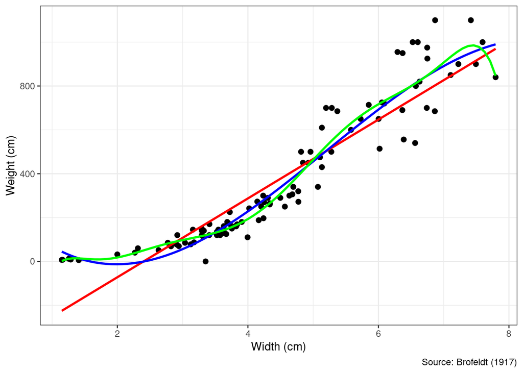

```r
# create scatter plot
ggplot(data = training, aes(x = Width, y = Weight)) +
  geom_point(size = 2) +
  geom_smooth(formula = y ~ x, method = 'lm', se = FALSE, color = 'red')+
  geom_smooth(formula = y ~ poly(x, 3), method = 'lm', se = FALSE, color = 'blue') +
  geom_smooth(formula = y ~ poly(x, 9), method = 'lm', se = FALSE, color = 'green') +
  labs(tite = 'Body measurements of freshwater fish',
       x = 'Width (cm)',
       y = 'Weight (cm)',
       caption = 'Source: Brofeldt (1917)') +
  theme_bw()
```

The graphic depicts three different regression models we might choose to employ. The red line is the linear model, which has the following equation:

$$y=179.738x-431.534$$

The linear model is the *least* flexible because it only involves the estimation of two parameters (intercept and slope). The blue curve represents a third-order polynomial with the following equation:

$$y=-7.842x^3+122.018x^2-392.008x+345.775$$

The cubic model is more flexible than the linear because additional parameters permit curvature that better fits the data. Finally, we take the flexibility to the extreme with the 9th-order polynomial depicted by the green curve with the following equation:

$$y=0.009x^9-0.530x^8+\cdots+13,220x-4,471$$

The more parameters we include in the model, the greater the capacity to match “wiggly” shapes in the data. In the most extreme case, we might attempt to develop a model that “connects the dots” represented by each observation. Next, we discuss the pros and cons of flexible versus inflexible models.

# Bias versus Variance

The accuracy of any statistical learning model can be decomposed into three types of error: bias, variance, and irreducible. **Irreducible** error exists in all stochastic processes simply due to their random nature. Thus, there is nothing we can do about irreducible error. **Bias** is the error that results from approximating a real-world system with a mathematical model. We can reduce this source of error by finding a model that fits the data well. Finally, **variance** is the error that results from fitting the model using training data that only represents a small subset of the population. Different training sets result in different parameter estimates and thus different predictions. We can reduce this type of error by not overfitting the data with too flexible of a model.

Let’s discuss the bias and variance sources of error by computing the root mean squared error (RMSE) for each model. Remember, we use the testing data to compute this measure of accuracy.

```r
# fit the three models
model1 <- lm(Weight ~ Width, data = training)
model2 <- lm(Weight ~ poly(Width, 3, raw = TRUE), data = training)
model3 <- lm(Weight ~ poly(Width, 9, raw = TRUE), data= training)

# predict weight using each model
fish_predict <- testing %>%
  mutate(
    Weight1 = predict(model1, newdata = testing),
    Weight2 = predict(model2, newdata = testing),
    Weight3 = predict(model3, newdata = testing)
  )

# compute RMSE for all models
fish_predict %>%
  summarize(
    RMSE1 = sqrt(mean((Weight - Weight1)^2)),
    RMSE2 = sqrt(mean((Weight - Weight2)^2)),
    RMSE3 = sqrt(mean((Weight - Weight3)^2))
  )
```

| RMSE1 | RMSE2 | RMSE3 |
| --- | --- | --- |
| 128.6205 | 78.33184 | 164.1068 |

```r
# another way of calculating rmse
library(Metrics)
fish_predict %>%
  summarize(
    RMSE1 = rmse(Weight, Weight1),
    RMSE2 = rmse(Weight, Weight2),
    RMSE3 = rmse(Weight, Weight3)
  )
```

| RMSE1 | RMSE2 | RMSE3 |
| --- | --- | --- |
| 128.6205 | 78.33184 | 164.1068 |

The linear model has an error of about 129 grams, on average. By allowing more flexibility, the cubic model reduces the error to only 78 grams. However, when we permit an extreme amount of flexibility with the 9th-order model, we see an increase in error to 164 grams. How could a model that better tracks the data produce a greater error?! The answer lies in the bias-variance trade-off.

It turns out that we cannot “have our cake and eat it too” (Trivia: Who is this saying attributed to?). When we decrease the bias error of a model by making it more flexible, we simultaneously increase the variance error. When we moved from the linear model to the cubic model, the decrease in bias was enough to overwhelm the increase in variance. However, when we jumped to the 9th-order model, the increase in variance overtook the decrease in bias. Thus, our goal is to find the “sweet spot” where the total error (RMSE) is minimized.

# Training Set Variance

When we choose a model that is too flexible for the data in hand, we tend to overfit the training set. This means that the model is so tailored to the specific observations in the training data that it misses the more general pattern in the population. Think of this as “missing the forest for the trees” (Trivia: Who came up with that one?). As a result, when the model encounters new data it tends to perform poorly. Let’s demonstrate this by fitting the cubic and 9th-order functions using two different training sets.

We’ll start with the existing training set and review the parameter estimates for each model.

```r
# display parameter estimates
summary(model2)
```

```
##
## Call:
## lm(formula = Weight ~ poly(Width, 3, raw = TRUE), data = training)
##
## Residuals:
##      Min       1Q   Median       3Q      Max
## -271.693  -35.556   -4.593   34.932  231.412
##
## Coefficients:
##                             Estimate Std. Error t value Pr(>|t|)
## (Intercept)                  345.775     96.554   3.581 0.000526 ***
## poly(Width, 3, raw = TRUE)1 -392.008     79.964  -4.902 3.58e-06 ***
## poly(Width, 3, raw = TRUE)2  122.018     20.335   6.000 3.03e-08 ***
## poly(Width, 3, raw = TRUE)3   -7.842      1.572  -4.990 2.49e-06 ***
## ---
## Signif. codes:  0 '***' 0.001 '**' 0.01 '*' 0.05 '.' 0.1 ' ' 1
##
## Residual standard error: 86.98 on 102 degrees of freedom
## Multiple R-squared:  0.9245, Adjusted R-squared:  0.9223
## F-statistic: 416.2 on 3 and 102 DF,  p-value: < 2.2e-16
```

```r
summary(model3)
```

```
##
## Call:
## lm(formula = Weight ~ poly(Width, 9, raw = TRUE), data = training)
##
## Residuals:
##      Min       1Q   Median       3Q      Max
## -270.556  -21.652   -1.308   25.861  224.801
##
## Coefficients:
##                               Estimate Std. Error t value Pr(>|t|)
## (Intercept)                 -4.471e+03  1.219e+04  -0.367    0.715
## poly(Width, 9, raw = TRUE)1  1.322e+04  3.488e+04   0.379    0.706
## poly(Width, 9, raw = TRUE)2 -1.604e+04  4.186e+04  -0.383    0.702
## poly(Width, 9, raw = TRUE)3  1.047e+04  2.776e+04   0.377    0.707
## poly(Width, 9, raw = TRUE)4 -4.041e+03  1.126e+04  -0.359    0.720
## poly(Width, 9, raw = TRUE)5  9.578e+02  2.907e+03   0.329    0.743
## poly(Width, 9, raw = TRUE)6 -1.391e+02  4.800e+02  -0.290    0.773
## poly(Width, 9, raw = TRUE)7  1.186e+01  4.906e+01   0.242    0.810
## poly(Width, 9, raw = TRUE)8 -5.304e-01  2.826e+00  -0.188    0.852
## poly(Width, 9, raw = TRUE)9  9.095e-03  7.011e-02   0.130    0.897
##
## Residual standard error: 84.4 on 96 degrees of freedom
## Multiple R-squared:  0.9331, Adjusted R-squared:  0.9268
## F-statistic: 148.7 on 9 and 96 DF,  p-value: < 2.2e-16
```

As a comparison, let’s now change the training data from which the models are constructed. We can do this by simply changing the randomization seed that splits the original data.

```r
# set randomization seed
set.seed(303)

# randomly select training rows
rows2 <- sample(x = 1:142, size = 106, replace = FALSE)

# extract training and testing sets
training2 <- fish[rows2, ]
testing2 <- fish[-rows2, ]

# fit new models
model22 <- lm(Weight ~ poly(Width, 3, raw = TRUE), data = training2)
model32 <- lm(Weight ~ poly(Width, 9, raw = TRUE), data = training2)
```

We now have new cubic and 9th-order models that were trained on a different subset of the data than the previous models. Let’s compare the parameter estimates to before, starting with the cubic model.

```r
# display parameter estimates
summary(model22)
```

```
##
## Call:
## lm(formula = Weight ~ poly(Width, 3, raw = TRUE), data = training2)
##
## Residuals:
##      Min       1Q   Median       3Q      Max
## -262.166  -36.608   -5.875   31.015  242.471
##
## Coefficients:
##                             Estimate Std. Error t value Pr(>|t|)
## (Intercept)                  309.538     80.936   3.824 0.000226 ***
## poly(Width, 3, raw = TRUE)1 -358.625     69.353  -5.171 1.17e-06 ***
## poly(Width, 3, raw = TRUE)2  114.545     17.610   6.505 2.94e-09 ***
## poly(Width, 3, raw = TRUE)3   -7.384      1.343  -5.499 2.84e-07 ***
## ---
## Signif. codes:  0 '***' 0.001 '**' 0.01 '*' 0.05 '.' 0.1 ' ' 1
##
## Residual standard error: 87.42 on 102 degrees of freedom
## Multiple R-squared:  0.9268, Adjusted R-squared:  0.9246
## F-statistic: 430.4 on 3 and 102 DF,  p-value: < 2.2e-16
```

The parameter estimates did change some, as we would expect. But the changes are not dramatic. For example, the coefficient on the cubic term changed from -7.842 to -7.384. That is an increase of only about 6%. Similarly, the quadratic term changed from 122.018 to 114.545. That is a decrease of about 6%. Now, let’s make the same comparison for the 9th-order model.

```r
# display parameter estimates
summary(model32)
```

```
##
## Call:
## lm(formula = Weight ~ poly(Width, 9, raw = TRUE), data = training2)
##
## Residuals:
##      Min       1Q   Median       3Q      Max
## -277.824  -26.369   -3.649   24.598  233.673
##
## Coefficients:
##                               Estimate Std. Error t value Pr(>|t|)
## (Intercept)                 -3.743e+03  7.070e+03  -0.529    0.598
## poly(Width, 9, raw = TRUE)1  1.180e+04  2.084e+04   0.566    0.573
## poly(Width, 9, raw = TRUE)2 -1.529e+04  2.564e+04  -0.596    0.553
## poly(Width, 9, raw = TRUE)3  1.070e+04  1.732e+04   0.618    0.538
## poly(Width, 9, raw = TRUE)4 -4.475e+03  7.101e+03  -0.630    0.530
## poly(Width, 9, raw = TRUE)5  1.169e+03  1.842e+03   0.635    0.527
## poly(Width, 9, raw = TRUE)6 -1.919e+02  3.037e+02  -0.632    0.529
## poly(Width, 9, raw = TRUE)7  1.925e+01  3.084e+01   0.624    0.534
## poly(Width, 9, raw = TRUE)8 -1.077e+00  1.758e+00  -0.613    0.541
## poly(Width, 9, raw = TRUE)9  2.579e-02  4.300e-02   0.600    0.550
##
## Residual standard error: 86.94 on 96 degrees of freedom
## Multiple R-squared:  0.9318, Adjusted R-squared:  0.9254
## F-statistic: 145.8 on 9 and 96 DF,  p-value: < 2.2e-16
```

The coefficient on the 9th-order term changed from 0.009 to 0.026, for an increase of 189%! Similarly, the 8th-order term changed from -0.530 to -1.077, for an decrease of 103%. The dramatic changes in coefficient estimates for highly-flexible models are the driving force behind variance error. What impact do these variations have on our assessment of accuracy?

```r
# predict weight using each model
testing2 %>%
  mutate(
    Weight2 = predict(model22, newdata = testing2),
    Weight3 = predict(model32, newdata = testing2)
  ) %>%
  summarize(
    RMSE2 = sqrt(mean((Weight - Weight2)^2)),
    RMSE3 = sqrt(mean((Weight - Weight3)^2))
  )
```

| RMSE2 | RMSE3 |
| --- | --- |
| 77.8921 | 74.33494 |

Notice the RMSE for the cubic model is very similar to that of our previous training/testing split (78.33 versus 77.89). However, the RMSE for the 9th-order model is *dramatically* different (164.11 versus 74.33). Now it appears the 9th-order model is more accurate than the cubic. Yet, we know this is not always the case because of our previous split. The significant change in accuracy once again exemplifies the variance in highly-flexible models.